# Module vs Attainment

Chinomnso Ekwedike

The aim of this analysis is to discover if there is any correlation between Modules and the student Attainment.

### **Prerequisites**

Load the libraries

```r
# load libraries
suppressPackageStartupMessages(library(dplyr))
suppressPackageStartupMessages(library(readr))
suppressPackageStartupMessages(library(ggplot2))
suppressPackageStartupMessages(library(ggvis))
suppressPackageStartupMessages(library(plotrix))
suppressPackageStartupMessages(library(patchwork))
suppressPackageStartupMessages(library(knitr))
```

Load the data sets needed for the analysis.

```r
# load data

# load the student information data set
s_info = read_csv("data/studentInfo.csv", show_col_types = FALSE)

# load the courses data set
courses = read_csv("data/courses.csv", show_col_types = FALSE)

# load the student registration data set
student_Reg = read_csv("data/studentRegistration.csv", show_col_types = FALSE)

# load the assessments data set
assessments = read_csv("data/assessments.csv", show_col_types = FALSE)

# load the student assessment data set
student_Assessment = read_csv("data/studentAssessment.csv", show_col_types = FALSE)

# load the student VLE data set
student_Vle = read_csv("data/studentVle.csv", show_col_types = FALSE)

# load the VLE data set
vle = read_csv("data/vle.csv", show_col_types = FALSE)
```

### **Exploratory Data Analysis**

Check the dimension of each data set. Also check for any missing rows

```r
# create a list of the tables
Datasets = c("Student_Info", "Courses", "Student_Reg", "Assessments", "Student_Assess", "Student_Vle", "Vle")

# create a list containing the number of rows contained in each table
Rows = c(nrow(s_info), nrow(courses), nrow(student_Reg), nrow(assessments), nrow(student_Assessment), nrow(student_Vle), nrow(vle))

# create a list containing the number of columns contained in each table
Columns = c(ncol(s_info), ncol(courses), ncol(student_Reg), ncol(assessments), ncol(student_Assessment), ncol(student_Vle), ncol(vle))

# create a list for missing rows/observations
Missing_rows = c(any(is.na(s_info)), any(is.na(courses)), any(is.na(student_Reg)), any(is.na(assessments)), any(is.na(student_Assessment)), any(is.na(student_Vle)), any(is.na(vle)))

# create a data frame containing the lists of values
df =  data.frame(Datasets, Rows, Columns, Missing_rows)

# display the data frame as a Knitr table
kable(df, caption = "Summary of Data Set Dimensions")
```

Summary of Data Set Dimensions

| Datasets | Rows | Columns | Missing_rows |
| --- | --- | --- | --- |
| Student_Info | 32593 | 12 | TRUE |
| Courses | 22 | 3 | FALSE |
| Student_Reg | 32593 | 5 | TRUE |
| Assessments | 206 | 6 | TRUE |
| Student_Assess | 173912 | 5 | TRUE |
| Student_Vle | 10655280 | 6 | FALSE |
| Vle | 6364 | 6 | TRUE |

```r
# print the first few rows of the student information data set
kable(head(s_info, 5))
```

| code_module | code_presentation | id_student | gender | region | highest_education | imd_band | age_band | num_of_prev_attempts | studied_credits | disability | final_result |
| --- | --- | --- | --- | --- | --- | --- | --- | --- | --- | --- | --- |
| AAA | 2013J | 11391 | M | East Anglian Region | HE Qualification | 90-100% | 55<= | 0 | 240 | N | Pass |
| AAA | 2013J | 28400 | F | Scotland | HE Qualification | 20-30% | 35-55 | 0 | 60 | N | Pass |
| AAA | 2013J | 30268 | F | North Western Region | A Level or Equivalent | 30-40% | 35-55 | 0 | 60 | Y | Withdrawn |
| AAA | 2013J | 31604 | F | South East Region | A Level or Equivalent | 50-60% | 35-55 | 0 | 60 | N | Pass |
| AAA | 2013J | 32885 | F | West Midlands Region | Lower Than A Level | 50-60% | 0-35 | 0 | 60 | N | Pass |

```r
# print the first few rows of the courses data set
kable(head(courses, 5))
```

| code_module | code_presentation | module_presentation_length |
| --- | --- | --- |
| AAA | 2013J | 268 |
| AAA | 2014J | 269 |
| BBB | 2013J | 268 |
| BBB | 2014J | 262 |
| BBB | 2013B | 240 |

```r
# print the first few rows of the student information data set
kable(head(student_Reg, 5))
```

| code_module | code_presentation | id_student | date_registration | date_unregistration |
| --- | --- | --- | --- | --- |
| AAA | 2013J | 11391 | -159 | NA |
| AAA | 2013J | 28400 | -53 | NA |
| AAA | 2013J | 30268 | -92 | 12 |
| AAA | 2013J | 31604 | -52 | NA |
| AAA | 2013J | 32885 | -176 | NA |

```r
# print the first few rows of the student information data set
kable(head(assessments, 5))
```

| code_module | code_presentation | id_assessment | assessment_type | date | weight |
| --- | --- | --- | --- | --- | --- |
| AAA | 2013J | 1752 | TMA | 19 | 10 |
| AAA | 2013J | 1753 | TMA | 54 | 20 |
| AAA | 2013J | 1754 | TMA | 117 | 20 |
| AAA | 2013J | 1755 | TMA | 166 | 20 |
| AAA | 2013J | 1756 | TMA | 215 | 30 |

```r
# print the first few rows of the student information data set
kable(head(student_Assessment, 5))
```

| id_assessment | id_student | date_submitted | is_banked | score |
| --- | --- | --- | --- | --- |
| 1752 | 11391 | 18 | 0 | 78 |
| 1752 | 28400 | 22 | 0 | 70 |
| 1752 | 31604 | 17 | 0 | 72 |
| 1752 | 32885 | 26 | 0 | 69 |
| 1752 | 38053 | 19 | 0 | 79 |

```r
# print the first few rows of the student information data set
kable(head(student_Vle, 5))
```

| code_module | code_presentation | id_student | id_site | date | sum_click |
| --- | --- | --- | --- | --- | --- |
| AAA | 2013J | 28400 | 546652 | -10 | 4 |
| AAA | 2013J | 28400 | 546652 | -10 | 1 |
| AAA | 2013J | 28400 | 546652 | -10 | 1 |
| AAA | 2013J | 28400 | 546614 | -10 | 11 |
| AAA | 2013J | 28400 | 546714 | -10 | 1 |

```r
# print the first few rows of the student information data set
kable(head(vle, 5))
```

| id_site | code_module | code_presentation | activity_type | week_from | week_to |
| --- | --- | --- | --- | --- | --- |
| 546943 | AAA | 2013J | resource | NA | NA |
| 546712 | AAA | 2013J | oucontent | NA | NA |
| 546998 | AAA | 2013J | resource | NA | NA |
| 546888 | AAA | 2013J | url | NA | NA |
| 547035 | AAA | 2013J | resource | NA | NA |

The different data sets are not balanced given that among the seven module codes used, three(`AAA`, `BBB` and `GGG`) Social Sciences while the remaining four (`CCCC`, `DDD`, `EEE` and `FFF`) represent STEM. This increases the likelihood of the results of the data analysis being in favour of STEM, where population is considered.

### **Data Preparation**

Remove any missing rows from data sets. Also, remove demographic information from the student information data set as they are out of scope for this project.

```r
 # remove the columns containing the demographic data from the student information data
  # set as they are out of scope for this project
student_Info =  s_info %>% select(everything(), -gender, -region, -highest_education, -imd_band, -age_band)
```

```r
  # remove any missing rows from the student information data set
  st_inf = na.omit(student_Info)

  # remove any missing rows from the courses data set
 course = na.omit(courses)

  # remove any missing rows from the student registration data set
  st_reg = na.omit(student_Reg)

  # remove any missing rows from the assessments data set
  assess = na.omit(assessments)

  # remove any missing rows from the student assessment data set
  st_ass = na.omit(student_Assessment)

  # remove any missing rows from the student VLE data set
  st_vle = na.omit(student_Vle)

  # remove any missing rows from the VLE data set
  v_le = na.omit(vle)
```

```r
# create a list containing the number of rows contained in each table
New_Rows = c(nrow(st_inf), nrow(course), nrow(st_reg), nrow(assess), nrow(st_ass), nrow(st_vle), nrow(v_le))

# create a list containing the number of columns contained in each table
New_Columns = c(ncol(st_inf), ncol(course), ncol(st_reg), ncol(assess), ncol(st_ass), ncol(st_vle), ncol(v_le))

# create a list for missing rows/observations
New_Missing_Rows = c(any(is.na(st_inf)), any(is.na(course)), any(is.na(st_reg)), any(is.na(assess)), any(is.na(st_ass)), any(is.na(st_vle)), any(is.na(v_le)))

# create a data frame containing the lists of values
new_df =  data.frame(Datasets, New_Rows, New_Columns, New_Missing_Rows)

# display the data frame as a Knitr table
kable(new_df, caption = "New Summary of Data Set Dimensions after Data Preparation")
```

New Summary of Data Set Dimensions after Data Preparation

| Datasets | New_Rows | New_Columns | New_Missing_Rows |
| --- | --- | --- | --- |
| Student_Info | 32593 | 7 | FALSE |
| Courses | 22 | 3 | FALSE |
| Student_Reg | 10033 | 5 | FALSE |
| Assessments | 195 | 6 | FALSE |
| Student_Assess | 173739 | 5 | FALSE |
| Student_Vle | 10655280 | 6 | FALSE |
| Vle | 1121 | 6 | FALSE |

Print out the first few rows of the student information data set.

```r
kable(head(st_inf))
```

| code_module | code_presentation | id_student | num_of_prev_attempts | studied_credits | disability | final_result |
| --- | --- | --- | --- | --- | --- | --- |
| AAA | 2013J | 11391 | 0 | 240 | N | Pass |
| AAA | 2013J | 28400 | 0 | 60 | N | Pass |
| AAA | 2013J | 30268 | 0 | 60 | Y | Withdrawn |
| AAA | 2013J | 31604 | 0 | 60 | N | Pass |
| AAA | 2013J | 32885 | 0 | 60 | N | Pass |
| AAA | 2013J | 38053 | 0 | 60 | N | Pass |

### **Data Analysis**

##### **A. Social Sciences vs STEM**

This section compares student attainment in Social Sciences versus that of STEM using the `student information`.

Compute the total number rows for the student information data set

```r
student_total = st_inf %>% count()
student_total$n
```

```
[1] 32593
```

Compute the number of students in each category of the final result.

```r
student_result_number = table(st_inf$final_result)
student_result_number
```

```
Distinction        Fail        Pass   Withdrawn
       3024        7052       12361       10156
```

Compute and summarise the proportion/ distribution of each category of the final results.

```r
total_result_percentage = round(prop.table(table(st_inf$final_result)) * 100, 1)
cbind(Results = table(st_inf$final_result), Percentage = total_result_percentage)
```

```
            Results Percentage
Distinction    3024        9.3
Fail           7052       21.6
Pass          12361       37.9
Withdrawn     10156       31.2
```

Display the proportions on a pie chart.

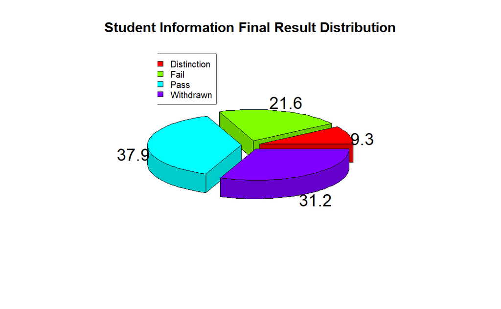

```r
# display the proportions on a pie chart
pie3D(student_result_number, labels = total_result_percentage, explode = 0.1, main = "Student Information Final Result Distribution", col = rainbow(4))
legend("topleft", c("Distinction", "Fail", "Pass", "Withdrawn"), cex = 0.8,
       fill = rainbow(4))
```

Display the different categories of final result for the full student information data set on a bar chart.

```r
# plot a bar chart showing the different results
st_inf %>% ggvis(~final_result, fill = ~final_result) %>% layer_bars()
```

[output not shown]

Starting with the Social Sciences modules Social sciences have `AAA`, `BBB` and `GGG` as codes for their modules

```r
# select the rows with the social sciences module codes
social_sciences = st_inf %>% select(everything()) %>% filter(code_module == "AAA" | code_module == "BBB" | code_module == "GGG")
```

Compute the total number of students in the Social Sciences

```r
ss_count = social_sciences %>% count()
ss_count$n
```

```
[1] 11191
```

Compute the percentage of Social Science students

```r
ss_percent = round((ss_count$n / student_total$n) * 100, 1)
paste(ss_percent,"%")
```

```
[1] "34.3 %"
```

Computing the number of each category of the final result

```r
result = table(social_sciences$final_result)
result
```

```
Distinction        Fail        Pass   Withdrawn
       1117        2586        4682        2806
```

Compute and summarise the proportion/ distribution of each category of the final results for the Social Sciences.

```r
soc_sci_perc = round(prop.table(table(social_sciences$final_result)) * 100, 1)
cbind(Results = table(social_sciences$final_result), Percentage = soc_sci_perc)
```

```
            Results Percentage
Distinction    1117       10.0
Fail           2586       23.1
Pass           4682       41.8
Withdrawn      2806       25.1
```

Display the proportions on a pie chart.

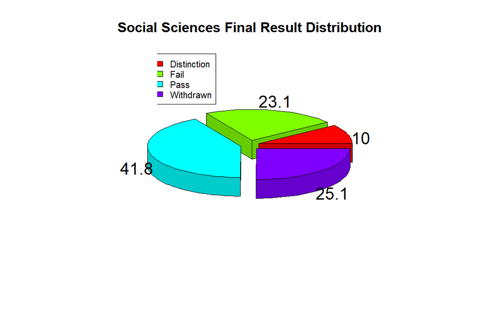

```r
# display the proportions on a pie chart
pie3D(result, labels = soc_sci_perc, explode = 0.1, main = "Social Sciences Final Result Distribution", col = rainbow(4))
legend("topleft", c("Distinction", "Fail", "Pass", "Withdrawn"), cex = 0.8,
   fill = rainbow(4))
```

Display the number of each category of the final result in a bar chart.

```r
# plot a bar chart showing the different results
social_sciences %>% ggvis(~final_result, fill = ~final_result) %>% layer_bars()
```

[output not shown]

```r
stem = st_inf %>% select(everything()) %>% filter(code_module == "CCC" | code_module == "DDD" | code_module == "EEE" | code_module == "FFF")
```

```r
stem_count = stem %>% count()
stem_count$n
```

```
[1] 21402
```

Compute the percentage of STEM student

```r
stem_percent = round((stem_count$n / student_total$n) * 100, 1)
paste(stem_percent,"%")
```

```
[1] "65.7 %"
```

```r
stem_result = table(stem$final_result)
stem_result
```

```
Distinction        Fail        Pass   Withdrawn
       1907        4466        7679        7350
```

Compute and summarise the proportion/ distribution of each category of the final results for STEM.

```r
stem_std_perc = round(prop.table(table(stem$final_result)) * 100, 1)
cbind(Results = table(stem$final_result), Percentage = stem_std_perc)
```

```
            Results Percentage
Distinction    1907        8.9
Fail           4466       20.9
Pass           7679       35.9
Withdrawn      7350       34.3
```

Display the proportions on a pie chart.

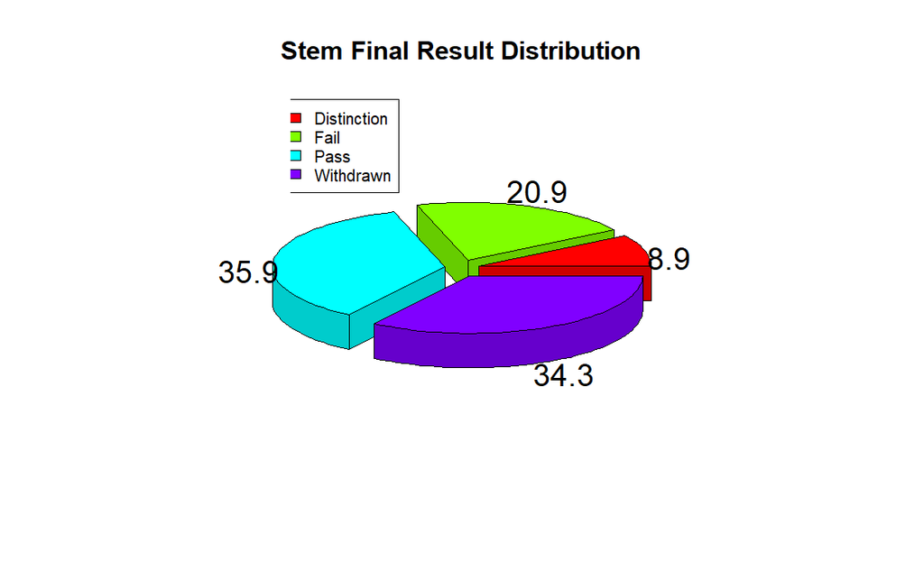

```r
# display the proportions on a pie chart
pie3D(stem_result, labels = stem_std_perc, explode = 0.1, main = "Stem Final Result Distribution", col = rainbow(4))
legend("topleft", c("Distinction", "Fail", "Pass", "Withdrawn"), cex = 0.8,
       fill = rainbow(4))
```

Display the number of the different categories in a bar chart.

```r
# plot a bar chart showing the different results
stem %>% ggvis(~final_result, fill = ~final_result) %>% layer_bars()
```

[output not shown]

```r
# Create a table of summary of the findings
Modules = c("Full_Data", "Social_Sciences", "Stem")
Distinction = c(3024, 1117, 1907)
Fail = c(7052, 2586, 4466)
Pass = c(12361, 4682, 7679)
Withdrawn = c(10156, 2806, 7350)
Total = c(student_total$n, ss_count$n, stem_count$n)
Percentage_of_Total = c(100.0, 34.3, 65.7)
sum_df = data.frame(Modules, Distinction, Fail, Pass, Withdrawn, Total, Percentage_of_Total)
kable(sum_df)
```

| Modules | Distinction | Fail | Pass | Withdrawn | Total | Percentage_of_Total |
| --- | --- | --- | --- | --- | --- | --- |
| Full_Data | 3024 | 7052 | 12361 | 10156 | 32593 | 100.0 |
| Social_Sciences | 1117 | 2586 | 4682 | 2806 | 11191 | 34.3 |
| Stem | 1907 | 4466 | 7679 | 7350 | 21402 | 65.7 |

**Summary of Results:**

- Out of 32593, 21402 (65.7%) were STEM students while 11191 (34.3%) were Social Science students.
- In each category of results, STEM students had the highest number compared to Social Science students.
- In Distinction, Fail, Pass and Withdrawn, Social Sciences had the lower population of students with a value of 1117 (10.0%), 2586 (23.1), 4682 (41.8%) and 2806 (25.1%) respectively.
- In Distinction, Fail, Pass and Withdrawn, STEM had a higher population of students with a value of 1907 (8.9%), 4466 (20.9), 7679 (35.9%) and 7350 (34.3%).
- Within the student population for both courses, the students with a pass (result) had the highest percentage, followed by those who withdrew, failed and had a distinction accordingly. This follows a similar order of distribution found in the full data set.

##### **B. Social Sciences vs STEM Based on Months**

This section covers a comparison of Social Sciences and STEM based on the months. This uses the `student information` data set.

Starting with the full data set

```r
full_months = table(st_inf$code_presentation)
full_months
```

```
2013B 2013J 2014B 2014J
 4684  8845  7804 11260
```

Compute and summarise the proportion/ distribution of the different presentations.

```r
present_perc = round(prop.table(table(st_inf$code_presentation)) * 100, 1)
cbind(Presentation = table(st_inf$code_presentation), Percentage = present_perc)
```

```
      Presentation Percentage
2013B         4684       14.4
2013J         8845       27.1
2014B         7804       23.9
2014J        11260       34.5
```

Display the proportions on a pie chart.

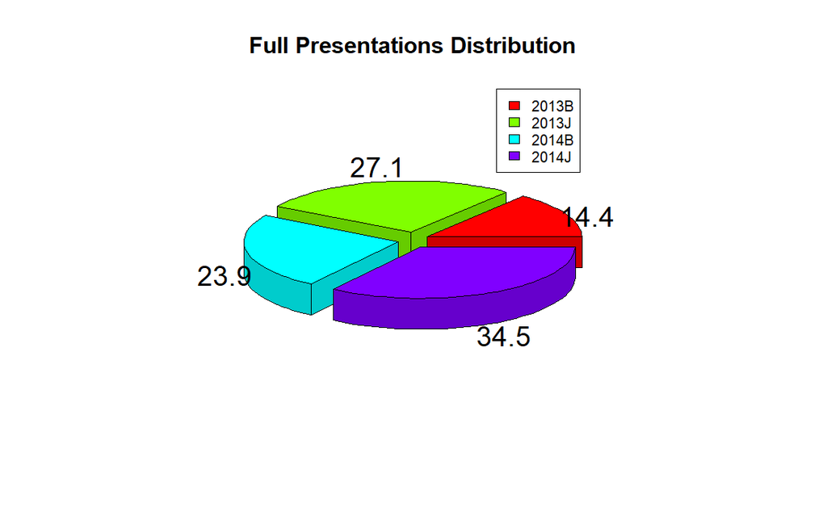

```r
# display the proportions on a pie chart
#pie(result, col = rainbow(4))
pie3D(full_months, labels = present_perc, explode = 0.1, main = "Full Presentations Distribution", col = rainbow(4))
legend("topright", c("2013B", "2013J", "2014B", "2014J"), cex = 0.8, fill = rainbow(4))
```

Display the presentations on a bar chart.

```r
# plot a bar chart showing the different results
st_inf %>% ggvis(~code_presentation, fill = ~code_presentation) %>% layer_bars()
```

[output not shown]

Compute the distribution of the different presentations for Social Sciences

```r
ss_months = table(social_sciences$code_presentation)
ss_months
```

```
2013B 2013J 2014B 2014J
 1767  3572  2446  3406
```

Compute and summarise the proportion/ distribution of each presentation.

```r
total_ss_percentage = round(prop.table(table(social_sciences$code_presentation)) * 100, 1)
cbind(Presentation = table(social_sciences$code_presentation), Percentage = total_ss_percentage)
```

```
      Presentation Percentage
2013B         1767       15.8
2013J         3572       31.9
2014B         2446       21.9
2014J         3406       30.4
```

Display the results on a pie chart.

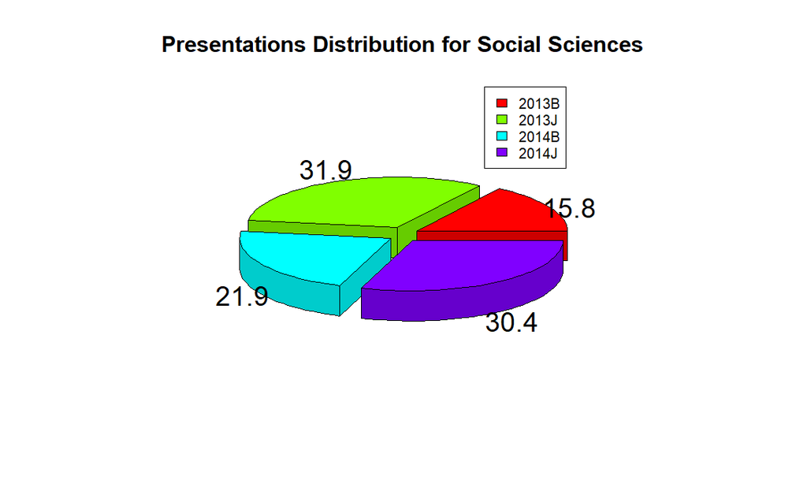

```r
# display the proportions on a pie chart
#pie(result, col = rainbow(4))
pie3D(ss_months, labels = total_ss_percentage, explode = 0.1, main = "Presentations Distribution for Social Sciences", col = rainbow(4))
legend("topright", c("2013B", "2013J", "2014B", "2014J"), cex = 0.8, fill = rainbow(4))
```

Display the number of each presentation on a bar chart.

```r
# plot a bar chart showing the different results
social_sciences %>% ggvis(~code_presentation, fill = ~code_presentation) %>% layer_bars()
```

[output not shown]

Compute the proportion of the final results for each month and year (presentation) for Social Sciences.

Starting with February 2013

```r
feb_2013 =  social_sciences %>% select(everything()) %>% filter(code_presentation == "2013B")
ss_2013B = table(feb_2013$final_result)
ss_2013B
```

```
Distinction        Fail        Pass   Withdrawn
        155         459         648         505
```

Compute and summarise the proportion/ distribution of each category of the final results for each presentation.

```r
result_2013_percentage = round(prop.table(table(feb_2013$final_result)) * 100, 1)
cbind(Presentation = table(feb_2013$final_result), Percentage = result_2013_percentage)
```

```
            Presentation Percentage
Distinction          155        8.8
Fail                 459       26.0
Pass                 648       36.7
Withdrawn            505       28.6
```

Display the proportions on a pie chart.

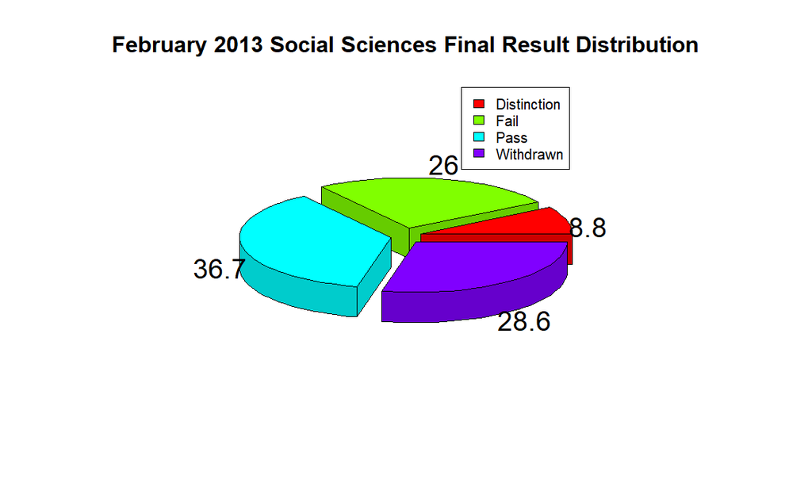

```r
# display the proportions on a pie chart
pie3D(ss_2013B, labels = result_2013_percentage, explode = 0.1, main = "February 2013 Social Sciences Final Result Distribution", col = rainbow(4))
legend("topright", c("Distinction", "Fail", "Pass", "Withdrawn"), cex = 0.8, fill = rainbow(4))
```

Display the numbers on a bar chart.

```r
# plot a bar chart showing the different results
feb_2013 %>% ggvis(~final_result, fill = ~final_result) %>% layer_bars()
```

[output not shown]

October 2013

```r
oct_2013 =  social_sciences %>% select(everything()) %>% filter(code_presentation == "2013J")
count_2013J = table(oct_2013$final_result)
count_2013J
```

```
Distinction        Fail        Pass   Withdrawn
        337         860        1605         770
```

Compute and summarise the proportion/ distribution of each category of the final results for each presentation.

```r
result_2013J_percentage = round(prop.table(table(oct_2013$final_result)) * 100, 1)
cbind(Presentation = table(oct_2013$final_result), Percentage = result_2013J_percentage)
```

```
            Presentation Percentage
Distinction          337        9.4
Fail                 860       24.1
Pass                1605       44.9
Withdrawn            770       21.6
```

Display the proportions on a pie chart.

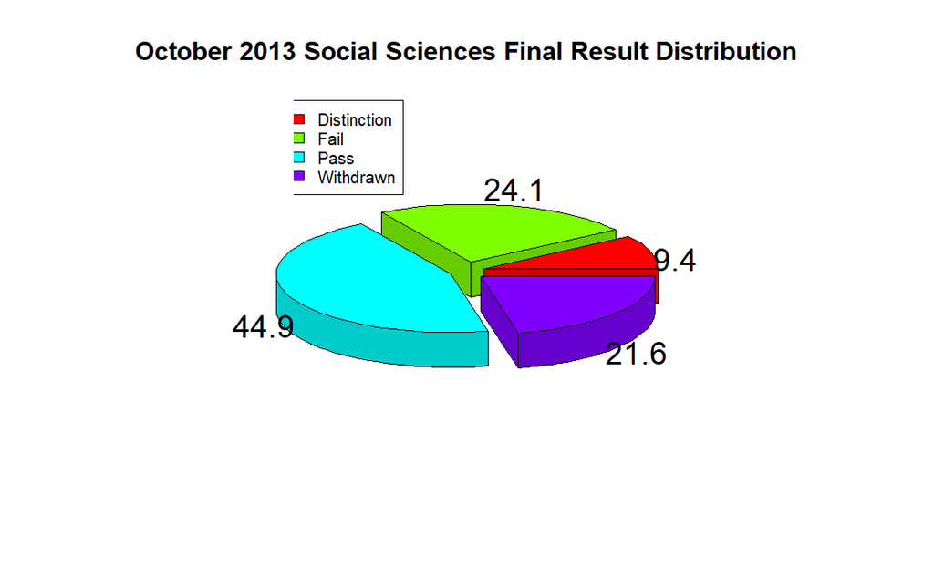

```r
# display the proportions on a pie chart
pie3D(count_2013J, labels = result_2013J_percentage, explode = 0.1, main = "October 2013 Social Sciences Final Result Distribution", col = rainbow(4))
legend("topleft", c("Distinction", "Fail", "Pass", "Withdrawn"), cex = 0.8, fill = rainbow(4))
```

Display the numbers on a bar chart.

```r
# plot a bar chart showing the different results
oct_2013 %>% ggvis(~final_result, fill = ~final_result) %>% layer_bars()
```

[output not shown]

February 2014

```r
feb_2014 =  social_sciences %>% select(everything()) %>% filter(code_presentation == "2014B")
ss_2014B = table(feb_2014$final_result)
ss_2014B
```

```
Distinction        Fail        Pass   Withdrawn
        294         651         911         590
```

Compute and summarise the proportion/ distribution of each category of the final results.

```r
total_2014B_percentage = round(prop.table(table(feb_2014$final_result)) * 100, 1)
cbind(Presentation = table(feb_2014$final_result), Percentage = total_2014B_percentage)
```

```
            Presentation Percentage
Distinction          294       12.0
Fail                 651       26.6
Pass                 911       37.2
Withdrawn            590       24.1
```

Compute and summarise the proportion/ distribution of each category of the final results.

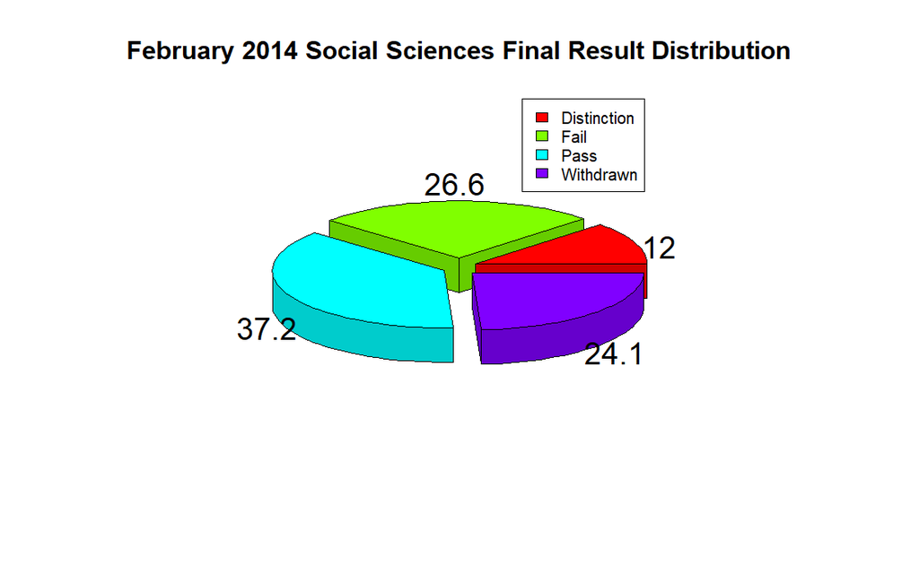

```r
# display the proportions on a pie chart
pie3D(ss_2014B, labels = total_2014B_percentage, explode = 0.1, main = "February 2014 Social Sciences Final Result Distribution", col = rainbow(4))
legend("topright", c("Distinction", "Fail", "Pass", "Withdrawn"), cex = 0.8, fill = rainbow(4))
```

Display the numbers on a bar chart.

```r
# plot a bar chart showing the different results
feb_2014 %>% ggvis(~final_result, fill = ~final_result) %>% layer_bars()
```

[output not shown]

October 2014

```r
oct_2014 =  social_sciences %>% select(everything()) %>% filter(code_presentation == "2014J")
ss_2014J_count = table(oct_2014$final_result)
ss_2014J_count
```

```
Distinction        Fail        Pass   Withdrawn
        331         616        1518         941
```

Compute and summarise the proportion/ distribution of each category of the final results.

```r
total_2014J_percentage_ss = round(prop.table(table(oct_2014$final_result)) * 100, 1)
cbind(Presentation = table(oct_2014$final_result), Percentage = total_2014J_percentage_ss)
```

```
            Presentation Percentage
Distinction          331        9.7
Fail                 616       18.1
Pass                1518       44.6
Withdrawn            941       27.6
```

Display the proportions on a pie chart.

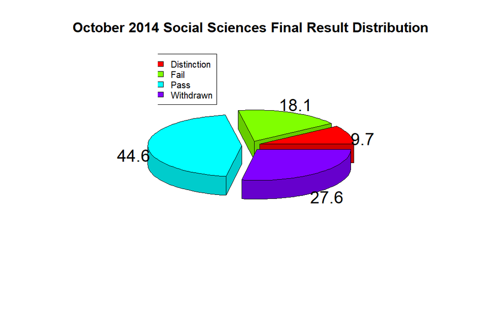

```r
# display the proportions on a pie chart
pie3D(ss_2014J_count, labels = total_2014J_percentage_ss, explode = 0.1, main = "October 2014 Social Sciences Final Result Distribution", col = rainbow(4))
legend("topleft", c("Distinction", "Fail", "Pass", "Withdrawn"), cex = 0.8, fill = rainbow(4))
```

Display the numbers on a bar chart.

```r
# plot a bar chart showing the different results
oct_2014 %>% ggvis(~final_result, fill = ~final_result) %>% layer_bars()
```

[output not shown]

Compute the proportion of the final results for each final results for each month and year for STEM.

Compute the number of students within each category of the final results for STEM

```r
stem_months = table(stem$code_presentation)
stem_months
```

```
2013B 2013J 2014B 2014J
 2917  5273  5358  7854
```

Compute and summarise the proportion/ distribution for STEM

```r
total_stem_percentage = round(prop.table(table(stem$code_presentation)) * 100, 1)
cbind(Presentation = table(stem$code_presentation), Percentage = total_stem_percentage)
```

```
      Presentation Percentage
2013B         2917       13.6
2013J         5273       24.6
2014B         5358       25.0
2014J         7854       36.7
```

Display the proportions on a pie chart.

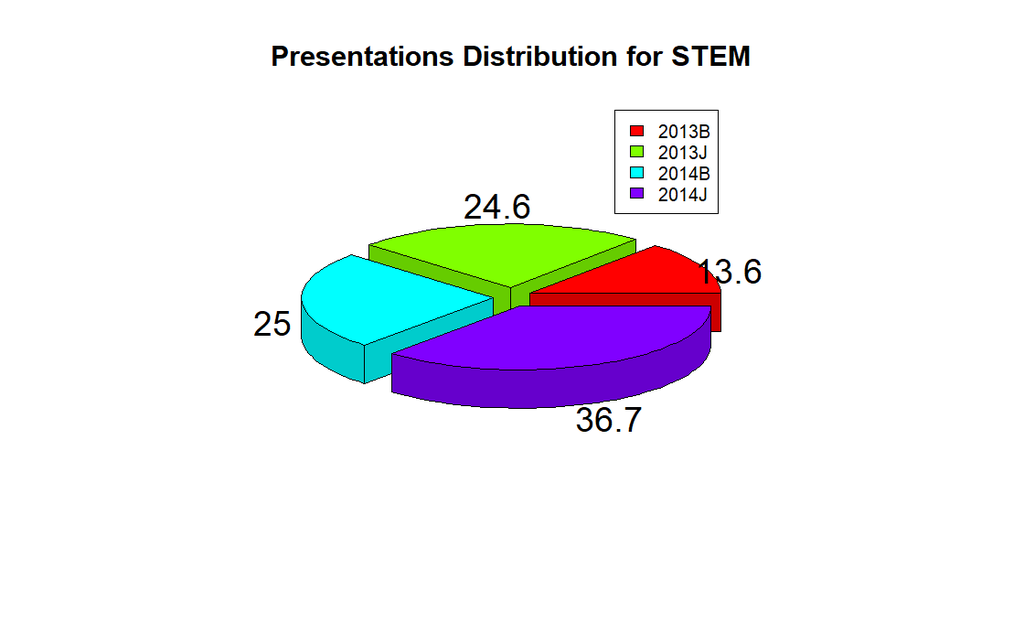

```r
# display the proportions on a pie chart
pie3D(stem_months, labels = total_stem_percentage, explode = 0.1, main = "Presentations Distribution for STEM", col = rainbow(4))
legend("topright", c("2013B", "2013J", "2014B", "2014J"), cex = 0.8, fill = rainbow(4))
```

Display the number of each presentation on a bar chart.

```r
# plot a bar chart showing the different results
stem %>% ggvis(~code_presentation, fill = ~code_presentation) %>% layer_bars()
```

[output not shown]

Starting with February 2013

```r
feb_2013_stem =  stem %>% select(everything()) %>% filter(code_presentation == "2013B")
feb_stem_13 = table(feb_2013_stem$final_result)
feb_stem_13
```

```
Distinction        Fail        Pass   Withdrawn
        172         782        1120         843
```

Compute and summarise the proportion/ distribution of each category of the final results.

```r
total_result2013B_perc = round(prop.table(table(feb_2013_stem$final_result)) * 100, 1)
cbind(Presentation = table(feb_2013_stem$final_result), Percentage = total_result2013B_perc)
```

```
            Presentation Percentage
Distinction          172        5.9
Fail                 782       26.8
Pass                1120       38.4
Withdrawn            843       28.9
```

Display the proportions on a pie chart.

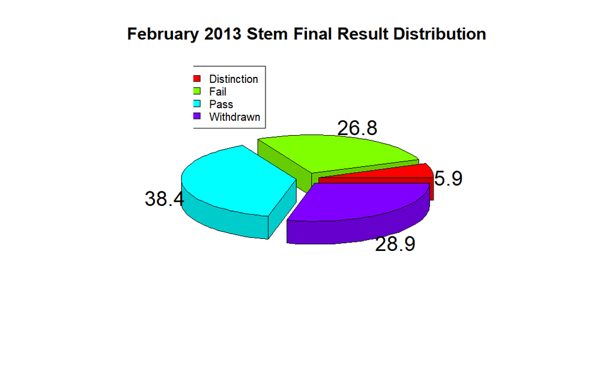

```r
# display the proportions on a pie chart
pie3D(feb_stem_13, labels = total_result2013B_perc, explode = 0.1, main = "February 2013 Stem Final Result Distribution", col = rainbow(4))
legend("topleft", c("Distinction", "Fail", "Pass", "Withdrawn"), cex = 0.8, fill = rainbow(4))
```

Display the results on a bar chart.

```r
# plot a bar chart showing the different results
feb_2013_stem %>% ggvis(~final_result, fill = ~final_result) %>% layer_bars()
```

[output not shown]

October 2013

```r
oct_2013_stem =  stem %>% select(everything()) %>% filter(code_presentation == "2013J")
stem_2013J = table(oct_2013_stem$final_result)
stem_2013J
```

```
Distinction        Fail        Pass   Withdrawn
        412        1141        2121        1599
```

Compute the proportion of each category of final result

```r
total_stem2013J_perc = round(prop.table(table(oct_2013_stem$final_result)) * 100, 1)
cbind(Presentation = table(oct_2013_stem$final_result), Percentage = total_stem2013J_perc)
```

```
            Presentation Percentage
Distinction          412        7.8
Fail                1141       21.6
Pass                2121       40.2
Withdrawn           1599       30.3
```

Display a pie chart showing the different proportions.

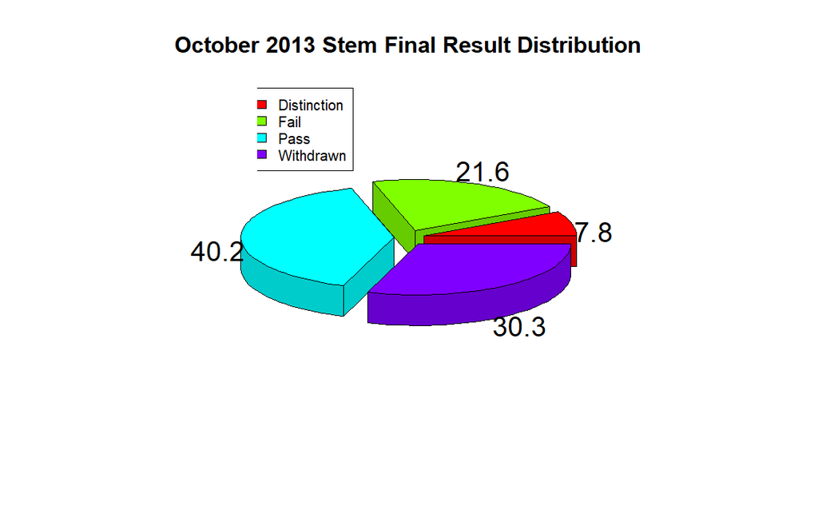

```r
# display the proportions on a pie chart
pie3D(stem_2013J, labels = total_stem2013J_perc, explode = 0.1, main = "October 2013 Stem Final Result Distribution", col = rainbow(4))
legend("topleft", c("Distinction", "Fail", "Pass", "Withdrawn"), cex = 0.8, fill = rainbow(4))
```

Display the results on a bar chart.

```r
# plot a bar chart showing the different results
oct_2013_stem %>% ggvis(~final_result, fill = ~final_result) %>% layer_bars()
```

[output not shown]